# M3: Hidden Markov Modeling for Accelerometer Data

Day 5 — Behavior Analysis Part 2

Animal Movement Analyses for Ecologists | SYSU Shenzhen, July 2026

28 July 2026

# Learning Objectives

By the end of this module you will be able to:

1. Fit a HMM to accelerometer data
2. Become comfortable with the Hmm workflow
3. Visualize output

**Packages used:** `momentuHMM`, `lubridate`, `tidyverse`

# Introduction

> Many thanks to Dr. Dongmin Kim for assistance in developing this material

We’ve now learned the basics of fitting an HMM. We’ll now take this one step further, incorporating data from accelerometers fitted on maned wolves (*Chrysocyon brachyurus*) in Parque Nacional da Serra da Canastra in Brazil.In these analyses, we will focus on two individuals (male: ID 32866 - Juba; female: ID 32733 - Pacoca). Juba and Pacoca are a mating pair and Pacoca was pregnant when she was fitted with the accelerometer. Many thanks to Dr. Rosanna N. Moraes for making these data available for use.

```r
# Remove items from memory/clean your workspace
rm(list=ls())

# You may need to install these packages first
#install.packages('momentuHMM', 'lubridate', 'tidyverse')

# Load libraries
library(momentuHMM)
library(lubridate)
library(tidyverse)
library(adehabitatLT)

# Load functions for later
source("utility_functions.R")
```

# 1. Load Data

The accelerometer data used in this module are saved in a proprietary format (i.e., .binv2) from the manufacterer (Vectronics Aerospace). In order to load the data into [R](https://cran.r-project.org/), I first used the manufacturer’s software to convert them to a R-readable format (i.e., .csv).

```r
# Load data

## ID: 32733 - pacoca
pacoca <- read.csv("data/32733_PACOCA/2022_pacoca_ACC.csv")

## ID: 32866 - juba
juba <- read.csv("data/32866_JUBA/2022_juba_ACC.csv")
```

# 2. Clean Timestamps

Note that the data currently do not have ID columns - we will create ID columns for each individual.

Note that the date and time columns (UTC_Date and UTC_Time, respectively) are organized as separately. Also, there is no information about “year” which we will create a year column and combine them together. Because these columns are “character” columns, we need to join them together and then convert them to a date/time field.

```r
## create ID for each dataframe
pacoca$ID <- "32733"
juba$ID <- "32866"

## create year column for each dataframe
pacoca$year <- "2022"
juba$year <- "2022"

## currently, the data contains several date/time columns -- year and date and time need to combine into one column first
## combine year, date, and time
pacoca$datetime_str <- paste(pacoca$year,
                             pacoca$UTC_Date,
                             pacoca$UTC_Time)

juba$datetime_str <- paste(juba$year,
                           juba$UTC_Date,
                           juba$UTC_Time)

## convert to POSIXct
pacoca$time <- lubridate::parse_date_time(
  pacoca$datetime_str,
  orders = "Y d-b HMS",
  tz = "UTC"
)

juba$time <- lubridate::parse_date_time(
  juba$datetime_str,
  orders = "Y d-b HMS",
  tz = "UTC"
)

## only select columns that will be used for this study
pacoca <- pacoca %>% dplyr::select(ID, time, x, y, z, temp)
juba <- juba %>% dplyr::select(ID, time, x, y, z, temp)
```

# 3. Dealing with gaps in tracks

The base time interval between observations was 2 seconds in this study. We need to make sure to check if there were missing observations, resulting in longer intervals that need to be corrected.

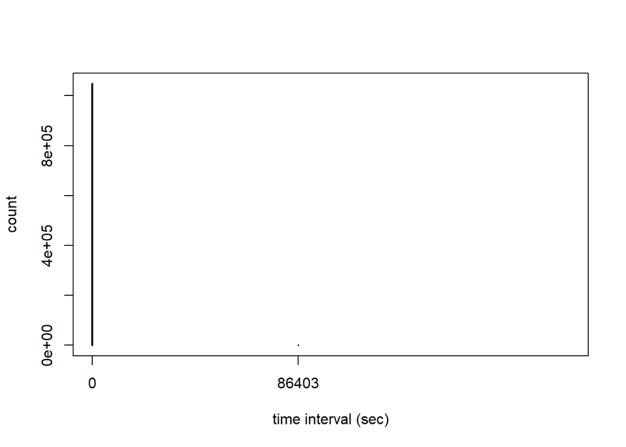

```r
# Table of time intervals in data - can apply to both individuals
plot(table(diff(juba$time)), xlim = c(0, 200000),
     xlab = "time interval (sec)", ylab = "count")
```

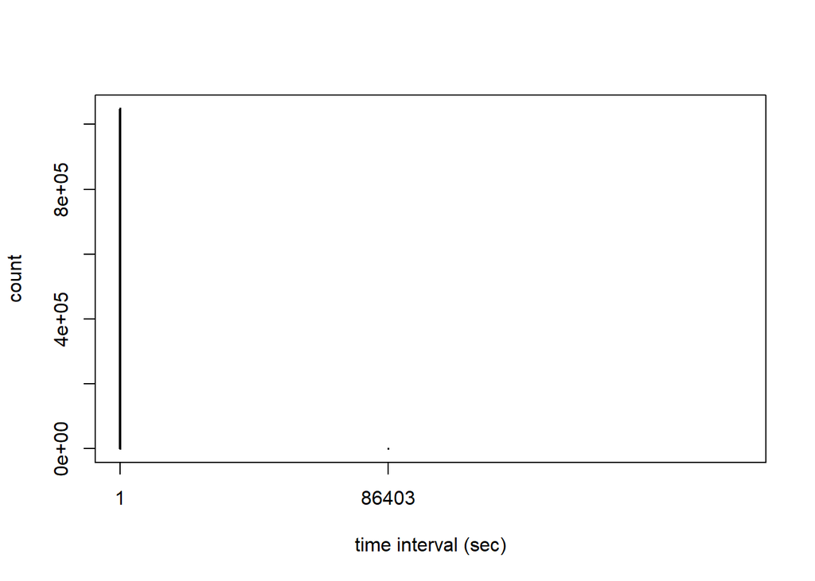

```r
plot(table(diff(pacoca$time)), xlim = c(0, 200000),
     xlab = "time interval (sec)", ylab = "count")
```

```r
# Check the large gaps in the tracks
diff_pacoca <- as.numeric(diff(pacoca$time), units = "secs")
diff_pacoca[diff_pacoca > 2]
```

```
##  [1]     6     3 86403    11     4    11     3     4    12     3    12     3
## [13]     3     4    11     4     3    11     3     4    12     3     3    12
## [25]     4    11     3     3     4    11 86403    11     3     3 86404    12
## [37] 86403     3     3    12 86404    11     3 86404    11     3 86404    12
## [49]     3 86403    12 86404    11     3     3 86404    11 86404     3    12
## [61] 86403    12     3     3 86405    11 86404    11     3 86404    12
```

```r
diff_juba <- as.numeric(diff(juba$time), units = "secs")
diff_juba[diff_juba > 2]
```

```
##  [1]     7 86403     3    12     3 86404    11     3 86403    12 86403    12
## [13]     3 86404    11 86404    11     3 86404    12     3 86403    12 86404
## [25]    11     3 86404    11 86404     3    12 86403    12     3 86404    11
## [37] 86404    11     3 86404    12 86403     3    12 86404    11     3 86404
## [49]    11     4    12     3 86403    12     4     3    11     4    11     3
## [61]     4    12     3    12
```

Inspection of the sampling intervals showed that most observations were collected every 2 seconds. However, we see some irregularities. These are common with accelerometer tags due to processing delays, or missed fixes.

Long gaps (1 day): We see that the logger stopped recording for about one day (86,403 seconds) and the resumed on the same 2-second smapling schedule. Because these long interruptions likely represent periods when no data were collected, the tracks were split at gaps greater than 30 minutes using the split_at_gap() utility function before fitting the HMM.

Small gaps (3-12 seconds): there are missing observations within an otherwise regular sampling schedule. Since the HMM requires regularizing the time series after splitting – we will do this after we calculating the ODBA.

```r
# Use function from utility_function.R to split data at gaps > 30 minutes
data_split_juba <- split_at_gap(data = juba, max_gap = 30, shortest_track = 0)
data_split_pacoca <- split_at_gap(data = pacoca, max_gap = 30, shortest_track = 0)
```

## 4. Calculating ODBA

Unlike GPS data, activity data do not include location information such as coordinates (e.g., Easting/Northing or latitude/longitude). Instead, activity data capture movement using proxy variables. In our data, these activity data are labeled as ‘x’, ‘y’, and ‘z’, measuring motion along three dimensions (X, Y, and Z - surge, sway, and heave). These values are recorded every 2 seconds and measure acceleration along the three body axes (X, Y, and Z; surge, sway, and heave).

These three measurements are often combined into a single summary metric called *Overall Dynamic Body Acceleration* or *ODBA*, representing the overall intensity of movement. ODBA is commonly used as an indicator of activity or energy expenditure.

Let’s calculate ODBA for our data. (Note that ODBA is calculated as the sume of the absolute values of the dynamic acceleration on each axis).

```r
## use a single summary activity variable - ODBA
data_split_pacoca$ODBA <-
  rowSums(abs(data_split_pacoca[, c("x", "y", "z")]))

data_split_juba$ODBA <-
  rowSums(abs(data_split_juba[, c("x", "y", "z")]))
```

## 5. Regular time intervals using NAs

Remember, there is still temporal irregularity in the data (3-12 seconds gaps). Hidden Markov models assume observatiosn occur at regular time intervals. Rather than splitting the tracks further, we retain these short interruptions and explicitly represent the missing observations by inserting rows with NA values.

Let’s create a complete sequence of timestamps at the expected 2-second sampling interval and merge the observed data onto this regular time grid. Any missing observations remain as NA and can be accommodated by momentuHMM.

```r
## Function to pad each split track to a regular 2-second time series
pad_time_series <- function(df, interval = 2){

  ## create regular timestamp sequence
  full_time <- data.frame(
    time = seq(
      from = min(df$time),
      to   = max(df$time),
      by   = interval
    )
  )

  ## merge observations onto regular timeline
  full_data <- dplyr::left_join(
    full_time,
    df,
    by = "time"
  )

  ## restore ID for inserted NA rows
  full_data$ID <- unique(df$ID)

  ## arrange columns
  full_data <- full_data %>%
    dplyr::select(ID, time, x, y, z, temp, ODBA)

  return(full_data)
}


## Apply padding separately to each split track
pacoca_regular <- data_split_pacoca %>%
  group_split(ID) %>%
  purrr::map_dfr(pad_time_series)

juba_regular <- data_split_juba %>%
  group_split(ID) %>%
  purrr::map_dfr(pad_time_series)
```

## 5.1. Further Data Wrangling

Let’s select several columns of interest for the analysis and combine both animals into a single dataframe.

```r
# select columns of interest
pacoca <- pacoca_regular %>%
  select(ID, ODBA, time, temp)

juba <- juba_regular %>%
  select(ID, ODBA, time, temp)

# combine datasets
data <- rbind(pacoca, juba)

# check the data summary
summary(data)
```

```
##       ID                 ODBA             time
##  Length:723612      Min.   :0.22     Min.   :2022-08-18 00:00:15
##  Class :character   1st Qu.:1.27     1st Qu.:2022-08-22 04:30:20
##  Mode  :character   Median :1.38     Median :2022-08-26 09:00:26
##                     Mean   :1.37     Mean   :2022-08-29 04:30:40
##                     3rd Qu.:1.47     3rd Qu.:2022-09-06 13:30:39
##                     Max.   :2.08     Max.   :2022-09-10 09:00:33
##                     NA's   :313686
##       temp
##  Min.   :14.00
##  1st Qu.:19.00
##  Median :21.00
##  Mean   :22.63
##  3rd Qu.:27.00
##  Max.   :41.00
##  NA's   :313686
```

# 6. The MomentuHMM Workflow

The data are now ready to be used in [momentuHMM](https://cran.r-project.org/web/packages/momentuHMM/index.html), following a similar set of steps that we are now familiar with, inclusive of the covariate temperature.

## 6.1 Data preparation

Note that we do not handle the location data like the GPS example. With GPS data, we derive step lengths and turning angles from the locations. Here, we set the ‘coordNames’ argument to NULL within the function ‘prepData’.

```r
# Prepare data for HMM
data_hmm <- prepData(data, coordNames = NULL, covNames = "temp")
```

## 6.2 Model Fitting

[MomentuHMM](https://cran.r-project.org/web/packages/momentuHMM/index.html) is quite flexible and can handle multiple datastreams, inclusive of GPS data for coarse-scale movements. Here, we will focus intently on the activity data only, using the function `fitHMM()` to fit models like we used previously.

Please once again refer to the [moveHMM](https://cran.r-project.org/web/packages/moveHMM/index.html) guide on selecting initial parameter values, as this can be very tricky: [A short guide to choosing initial parameter values for the estimation in moveHMM](https://cran.r-project.org/web/packages/moveHMM/vignettes/moveHMM-starting-values.pdf).

```r
# Observation distribution for ODBA
# ODBA is continuous and strictly positive, so a gamma distribution is appropriate.
# Missing ODBA values (created during temporal regularization) are retained in data_hmm
# and handled by momentuHMM.
dist <- list(ODBA = "gamma")

# Initial parameter values (Par0)
# Remove only missing values temporarily for calculating starting parameters.
# The original NA values remain in data_hmm for HMM fitting.
ODBA_obs <- data$ODBA[!is.na(data$ODBA)]

# Define initial means for the two activity states
# State 1: low-activity state
# Initialized using the lower half of observed ODBA values.
mu1 <- mean(ODBA_obs[ODBA_obs <= median(ODBA_obs)])

# State 2: high-activity state
# Initialized using the upper quartile of observed ODBA values.
mu2 <- mean(ODBA_obs[ODBA_obs >= quantile(ODBA_obs, 0.75)])

# Define initial standard deviations for each state
# These values describe the expected variability within each activity state.
# Small positive values are required because gamma parameters cannot be zero.
sd1 <- sd(ODBA_obs[ODBA_obs <= median(ODBA_obs)])
sd2 <- sd(ODBA_obs[ODBA_obs >= quantile(ODBA_obs, 0.75)])

# Combine into Par0
# The order is important: c(mu1, mu2, sd1, sd2)
Par0_2s <- list(
  ODBA = c(mu1, mu2, sd1, sd2)
)

# Fit a 2-state HMM
# Missing ODBA observations from the regularized time series remain as NA
# and are handled internally by momentuHMM.
hmm1 <- fitHMM(data_hmm,
               nbStates = 2,
               dist = dist,
               Par0 = Par0_2s)

# Print parameter estimates
hmm1
```

```
## Value of the maximum log-likelihood: 341727.6
##
##
## ODBA parameters:
## ----------------
##        state 1    state 2
## mean 1.2361277 1.46305931
## sd   0.1123885 0.09052572
##
## Regression coeffs for the transition probabilities:
## ---------------------------------------------------
##                1 -> 2    2 -> 1
## (Intercept) -3.848866 -4.219396
##
## Transition probability matrix:
## ------------------------------
##            state 1   state 2
## state 1 0.97914050 0.0208595
## state 2 0.01449434 0.9855057
##
## Initial distribution:
## ---------------------
##   state 1   state 2
## 0.4999282 0.5000718
```

## 6.3 Model Visualization

Similar to previous exercises, we see summary statistics and regression coefficients for model output. We can also plot the estimated distributions to visualize the findings.

```
## Decoding state sequence... DONE
```

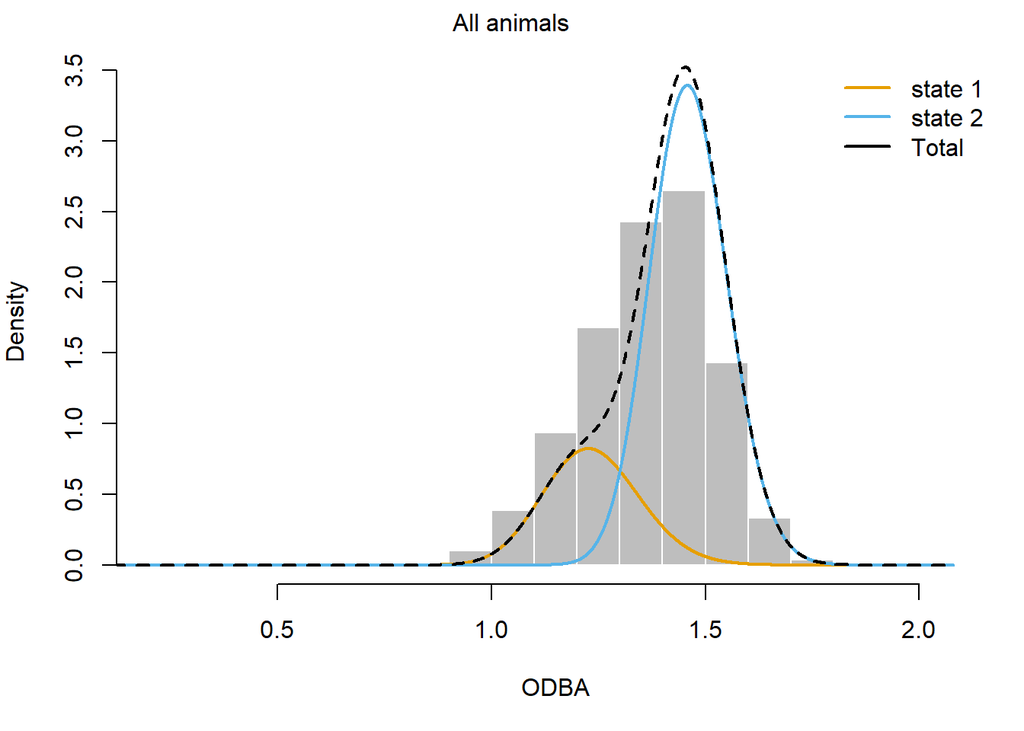

```r
# Plot estimated distributions and state-coloured tracks
plot(hmm1, ask = FALSE)
```

We can also estimate the most likely state sequence for a fitted model with the ‘viterbi’ algorithm.

```r
# get most likely sequence of states
head(viterbi(hmm1))
```

```
## [1] 1 1 1 1 1 1
```

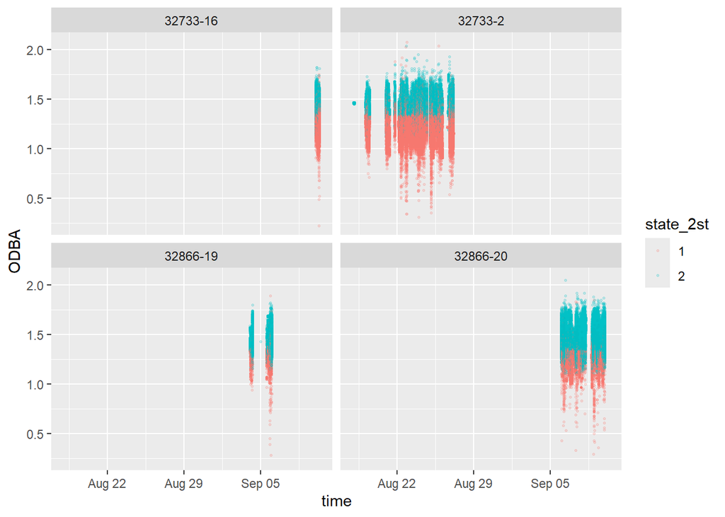

```r
# save most likely state sequence from 2-state model
data_hmm$state_2st <- factor(viterbi(hmm1))

# plot OBDA over time, colored by states
ggplot(data_hmm, aes(x = time, y = ODBA, col = state_2st, group = ID))+
  geom_point(size = 0.5, alpha = 0.2)+
  facet_wrap(~ID)
```

## 6.4 Model Formulation: Covariates

Now, following the same structure as previously, we will include the temperature measurements collected by the tag at each time of observation. Here, we aim to answer if temperature impacts maned wolf activity patterns. To do so, we’ll estimate the effect of temperature on the transition probabilities.

```r
# Fit 2-state HMM with temperature covariate
hmm2 <- fitHMM(data_hmm,
               nbStates = 2,
               dist = dist,
               Par0 = Par0_2s,
               formula = ~ temp)

# show summary of model 2
hmm2
```

```
## Value of the maximum log-likelihood: 341795.2
##
##
## ODBA parameters:
## ----------------
##        state 1    state 2
## mean 1.2361900 1.46315502
## sd   0.1123737 0.09045809
##
## Regression coeffs for the transition probabilities:
## ---------------------------------------------------
##                   1 -> 2      2 -> 1
## (Intercept) -3.727786668 -3.21364015
## temp        -0.005026343 -0.04421601
##
## Transition probability matrix (based on mean covariate values):
## ---------------------------------------------------------------
##            state 1    state 2
## state 1 0.97900444 0.02099556
## state 2 0.01448087 0.98551913
##
## Initial distribution:
## ---------------------
##   state 1   state 2
## 0.4966331 0.5033669
```

Visualizae the stationary state probabilities as a function of the temperature covariate.

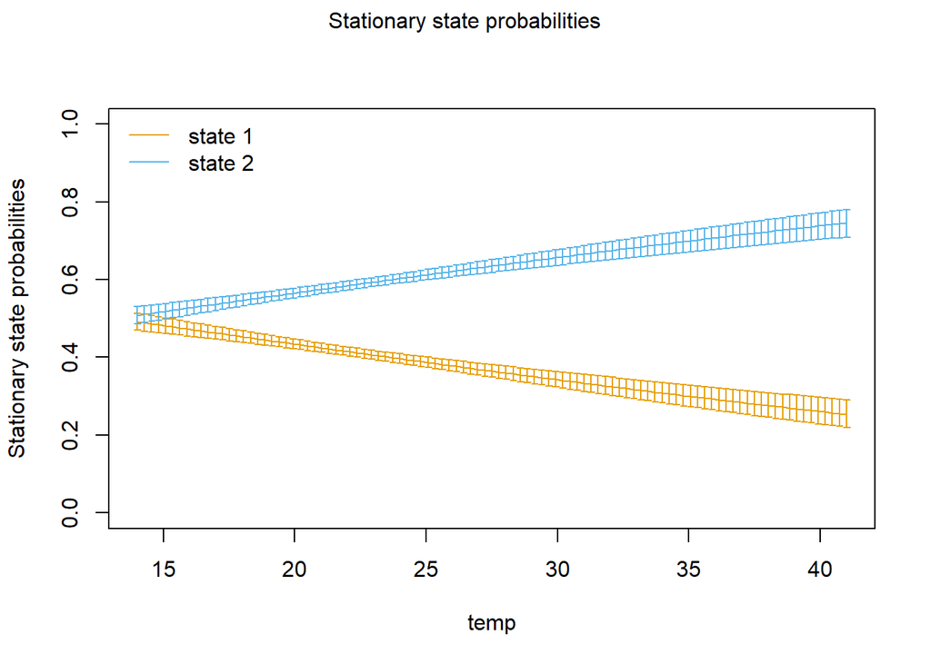

```r
# plot stationary state probabilities as functions of temperature
plotStationary(hmm2,
               plotCI = TRUE)
```

## 6.5 Model Comparison

We then use the function `AIC()` for model selection, comparing the model without the covariate versus model with the temperature covariate.

```r
# Compare models using AIC
AIC(hmm1,
    hmm2)
```

```
##   Model       AIC
## 1  hmm2 -683572.3
## 2  hmm1 -683441.2
```

These results indicate that the model (model 2) with the temperature covariate has more statistical support.